# Assignment_3

Eric Troudt

October 30, 2019

## PART 1

**a.** Based off the 7 different predictor variables, *Income* is the only one that does not have any missing values, while the remaining 6 variables each contain anywhere from 1500-1650 values (out of 32,561 observations) that are missing from the data set.

### **Before processing NAs**

```
##   Income           Age                   Workclass     Education.num
##  High: 7841   Min.   :17.00   Private         :21558   Min.   : 1.00
##  Low :24720   1st Qu.:28.00   Self-emp-not-inc: 2421   1st Qu.: 9.00
##               Median :37.00   Local-gov       : 1983   Median :10.00
##               Mean   :38.56   ?               : 1742   Mean   :10.08
##               3rd Qu.:48.00   State-gov       : 1239   3rd Qu.:12.00
##               Max.   :90.00   (Other)         : 2013   Max.   :16.00
##               NA's   :1641    NA's            : 1605   NA's   :1648
##                  Race           Sex        Hours.per.week
##  Amer-Indian-Eskimo:  298   Female:10240   Min.   : 1.00
##  Asian-Pac-Islander:  978   Male  :20687   1st Qu.:40.00
##  Black             : 2982   NA's  : 1634   Median :40.00
##  Other             :  259                  Mean   :40.46
##  White             :26515                  3rd Qu.:45.00
##  NA's              : 1529                  Max.   :99.00
##                                            NA's   :1591
```

**b.** To handle the NAs for the categorical variables, NA was added as another level. For quantitative variables, NAs were imputed using the ‘bagImpute’ method from caret.

### **After processing NAs**

```
##   Income                 Workclass                     Race
##  High: 7841   Private         :21558   Amer-Indian-Eskimo:  298
##  Low :24720   Self-emp-not-inc: 2421   Asian-Pac-Islander:  978
##               Local-gov       : 1983   Black             : 2982
##               ?               : 1742   Other             :  259
##               NA              : 1605   White             :26515
##               State-gov       : 1239   NA                : 1529
##               (Other)         : 2013
##      Sex             Age        Education.num   Hours.per.week
##  Female:10240   Min.   :17.00   Min.   : 1.00   Min.   : 1.00
##  Male  :20687   1st Qu.:28.00   1st Qu.: 9.00   1st Qu.:40.00
##  NA    : 1634   Median :38.00   Median :10.00   Median :40.00
##                 Mean   :38.55   Mean   :10.08   Mean   :40.46
##                 3rd Qu.:47.00   3rd Qu.:12.00   3rd Qu.:45.00
##                 Max.   :90.00   Max.   :16.00   Max.   :99.00
##
```

### **Non-pruned tree visual**

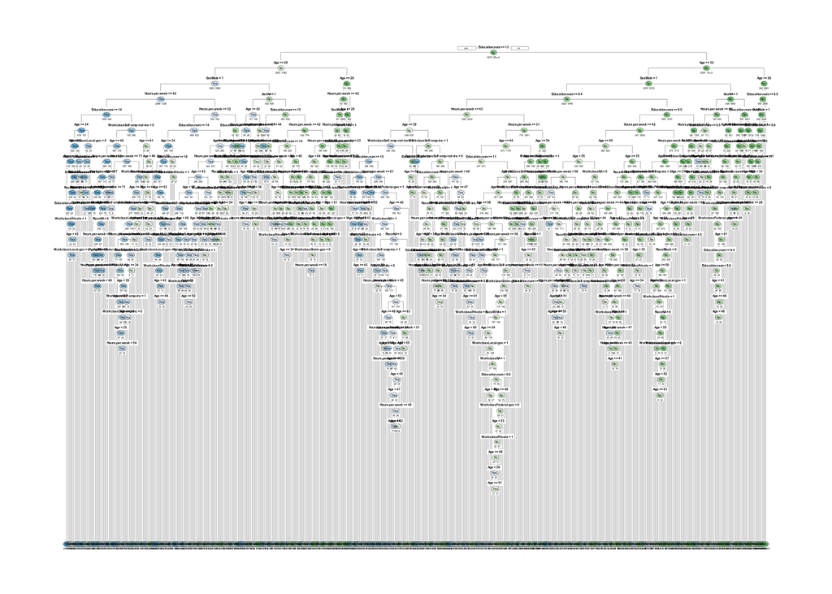

**c. - d.**

### **Training data Confusion Matrix/Statistics/ROC**

```
## Confusion Matrix and Statistics
##
##           Reference
## Prediction   Yes    No
##        Yes  2787  2085
##        No   3486 17691
##
##                Accuracy : 0.7861
##                  95% CI : (0.7811, 0.7911)
##     No Information Rate : 0.7592
##     P-Value [Acc > NIR] : < 2.2e-16
##
##                   Kappa : 0.3668
##
##  Mcnemar's Test P-Value : < 2.2e-16
##
##             Sensitivity : 0.4443
##             Specificity : 0.8946
##          Pos Pred Value : 0.5720
##          Neg Pred Value : 0.8354
##              Prevalence : 0.2408
##          Detection Rate : 0.1070
##    Detection Prevalence : 0.1870
##       Balanced Accuracy : 0.6694
##
##        'Positive' Class : Yes
##
```

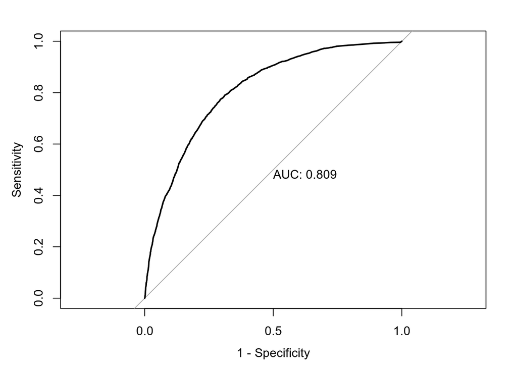

```
## Area under the curve: 0.8091
```

### **Test data Confusion Matrix/Statistics/ROC**

```
## Confusion Matrix and Statistics
##
##           Reference
## Prediction  Yes   No
##        Yes  702  548
##        No   866 4396
##
##                Accuracy : 0.7829
##                  95% CI : (0.7726, 0.7928)
##     No Information Rate : 0.7592
##     P-Value [Acc > NIR] : 3.421e-06
##
##                   Kappa : 0.3619
##
##  Mcnemar's Test P-Value : < 2.2e-16
##
##             Sensitivity : 0.4477
##             Specificity : 0.8892
##          Pos Pred Value : 0.5616
##          Neg Pred Value : 0.8354
##              Prevalence : 0.2408
##          Detection Rate : 0.1078
##    Detection Prevalence : 0.1920
##       Balanced Accuracy : 0.6684
##
##        'Positive' Class : Yes
##
```

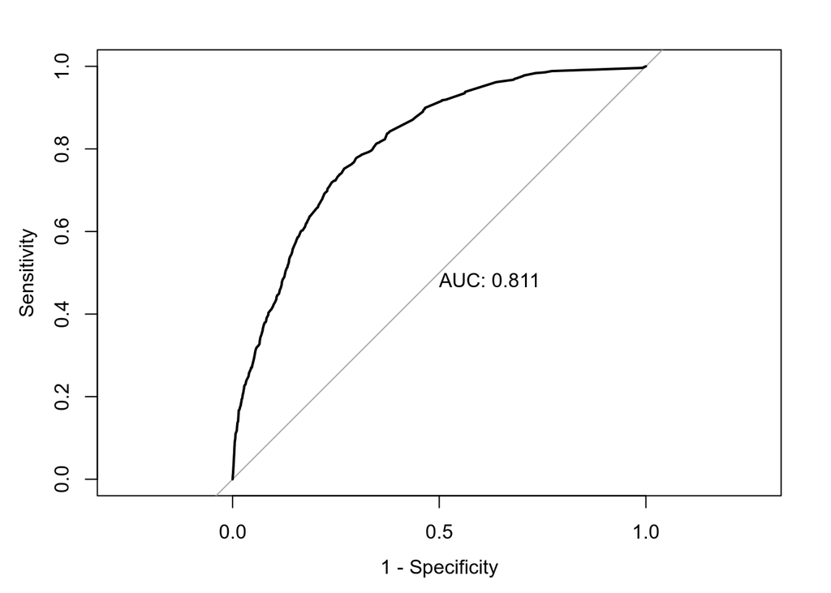

```
## Area under the curve: 0.8115
```

### __ Pruned tree visual__

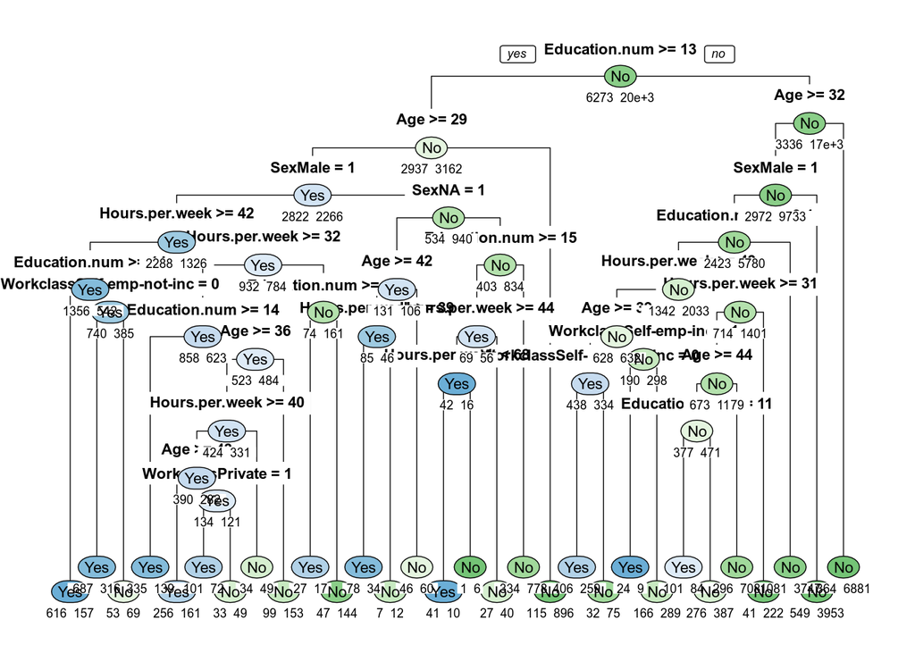

### __ Pruned tree Training data Confusion Matrix/Statistics/ROC__

```
## Confusion Matrix and Statistics
##
##           Reference
## Prediction    Yes     No
##        Yes  27151  16141
##        No   35579 181619
##
##                Accuracy : 0.8015
##                  95% CI : (0.7999, 0.803)
##     No Information Rate : 0.7592
##     P-Value [Acc > NIR] : < 2.2e-16
##
##                   Kappa : 0.3928
##
##  Mcnemar's Test P-Value : < 2.2e-16
##
##             Sensitivity : 0.4328
##             Specificity : 0.9184
##          Pos Pred Value : 0.6272
##          Neg Pred Value : 0.8362
##              Prevalence : 0.2408
##          Detection Rate : 0.1042
##    Detection Prevalence : 0.1662
##       Balanced Accuracy : 0.6756
##
##        'Positive' Class : Yes
##
```

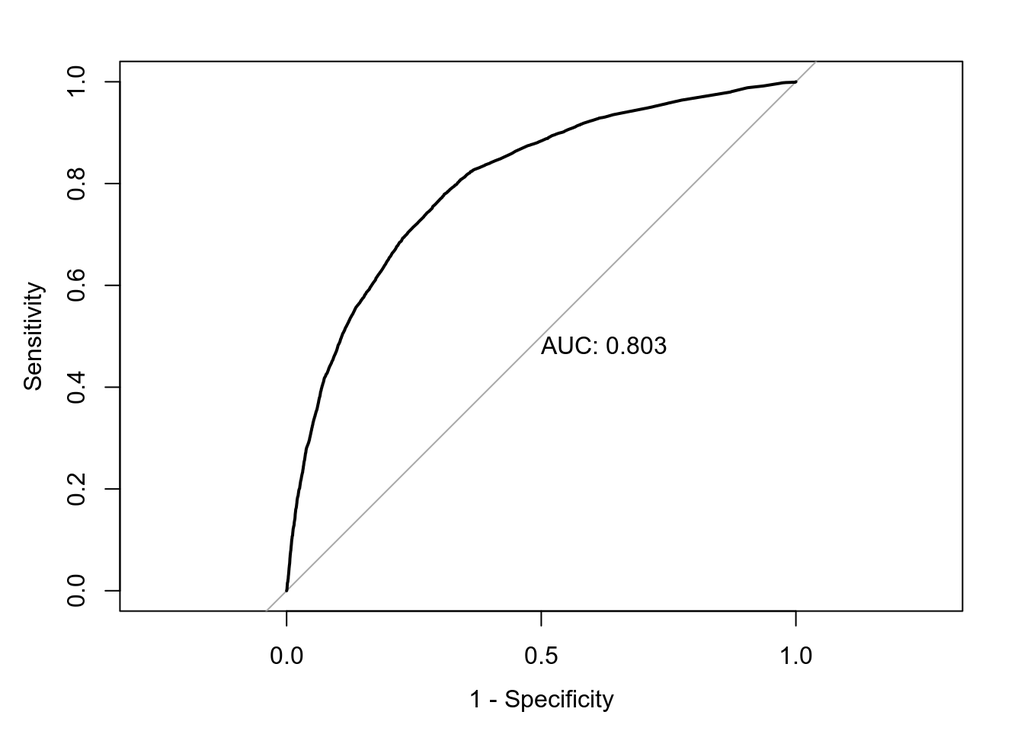

```
## Area under the curve: 0.8027
```

### **Pruned tree Test data Confusion Matrix/Statistics/ROC**

```
## Confusion Matrix and Statistics
##
##           Reference
## Prediction  Yes   No
##        Yes  664  358
##        No   904 4586
##
##                Accuracy : 0.8062
##                  95% CI : (0.7964, 0.8157)
##     No Information Rate : 0.7592
##     P-Value [Acc > NIR] : < 2.2e-16
##
##                   Kappa : 0.3984
##
##  Mcnemar's Test P-Value : < 2.2e-16
##
##             Sensitivity : 0.4235
##             Specificity : 0.9276
##          Pos Pred Value : 0.6497
##          Neg Pred Value : 0.8353
##              Prevalence : 0.2408
##          Detection Rate : 0.1020
##    Detection Prevalence : 0.1569
##       Balanced Accuracy : 0.6755
##
##        'Positive' Class : Yes
##
```

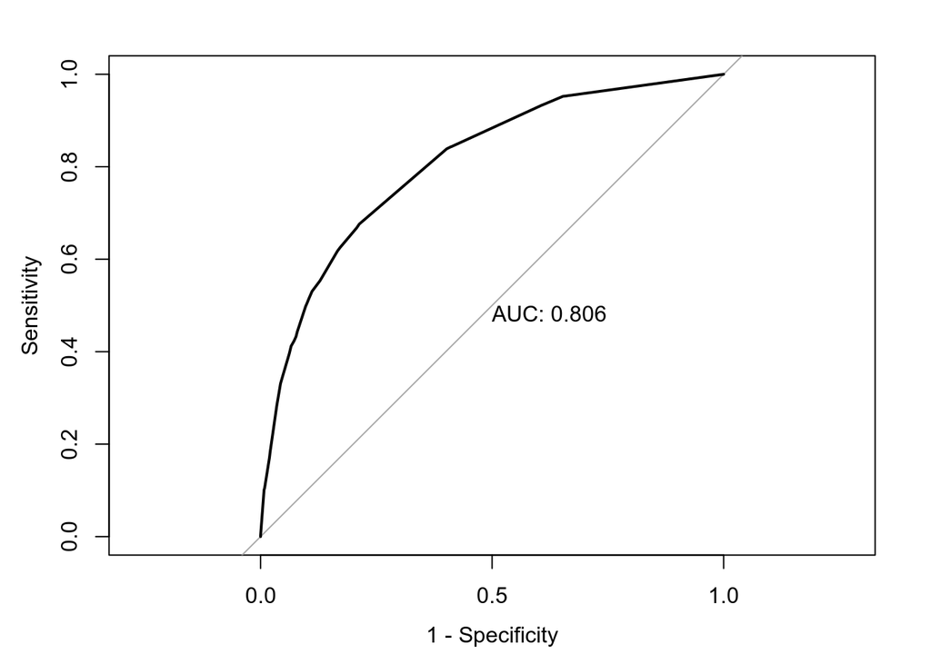

```
## Area under the curve: 0.8063
```

**f.** Compared with the pruned decision tree above, the random classifier performs poorly in every metric (accuracy, sensitivity, specificity, auc, kappa).

### **Random classifier Test data Confusion Matrix/Statistics/ROC**

```
## Confusion Matrix and Statistics
##
##           Reference
## Prediction  Yes   No
##        Yes  492 1587
##        No  1076 3357
##
##                Accuracy : 0.5911
##                  95% CI : (0.579, 0.603)
##     No Information Rate : 0.7592
##     P-Value [Acc > NIR] : 1
##
##                   Kappa : -0.0065
##
##  Mcnemar's Test P-Value : <2e-16
##
##             Sensitivity : 0.31378
##             Specificity : 0.67900
##          Pos Pred Value : 0.23665
##          Neg Pred Value : 0.75727
##              Prevalence : 0.24079
##          Detection Rate : 0.07555
##    Detection Prevalence : 0.31926
##       Balanced Accuracy : 0.49639
##
##        'Positive' Class : Yes
##
```

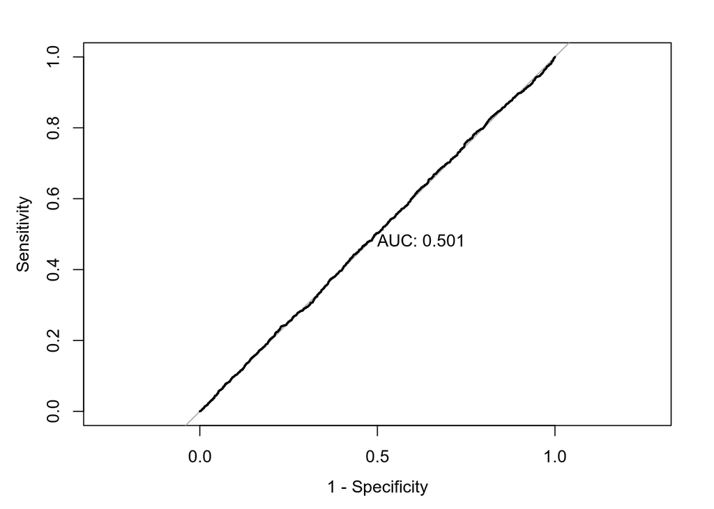

```
## Area under the curve: 0.5015
```

## PART 2

**a.**

Bagging: Addresses the issue of variability and over fitting inherent with single decision trees by aggregating numerous decision trees built with boot-strapped datasets of the original data. By aggregating or averaging the numerous trees, the variance can will be reduced and accuracy will improve.

Boosting: Addresses the issue of variability and over fitting inherent with single decision trees by building up a final decision tree from the subsequent generation of small, weak trees that rare fit based on prior prediction errors (residuals). In this way, boosting carries out a ‘slow learning’ process that relies on sequential improvement of one tree via incorporation of each weak tree into the overall model.

**b.**

Random forest is a modified version of bagging in which only m number of predictors can be selected from at any given split. A problem with bagging arises out of the top-down greedy approach to tree creation which inevitably leads to numerous bagged trees with similar splits among the internal nodes of the trees, especially during the first initial splits made. This in-turn leads to highly correlated predictions among the bagged trees, which ultimately leads to higher variability for the averaged prediction. Random forests prevent highly correlated trees by only allowing for a random selection of m predictors at any given split, providing for an estimate with reduced variability and overall better accuracy.

**c.- d.** Between the random forest models with mtry = 10 and mtry = 3 (below), allowing only 3 predictors at any split led to increased specificity and accuracy, lower sensitivity and kappa, and a slightly higher auc for the training data. Since the census dataset only has 6 predictor variables, setting mtry to > 6 essentially makes it a regular bagging tree, so the rf tree with mtry = 10’s predictions are more correlated, and therefore its model will be less robust and accurate, which is reflected in its lower auc and accuracy.

**e.** Based on the variable importance plot below, the three predictors with the largest mean decrease in gini index were Education.num, Age, and hours.per.week.

### **Random Forest (mtry = 10) training data Confusion Matrix/Statistics/ROC**

```
## Confusion Matrix and Statistics
##
##           Reference
## Prediction   Yes    No
##        Yes  2816  2022
##        No   3457 17754
##
##                Accuracy : 0.7897
##                  95% CI : (0.7847, 0.7946)
##     No Information Rate : 0.7592
##     P-Value [Acc > NIR] : < 2.2e-16
##
##                   Kappa : 0.376
##
##  Mcnemar's Test P-Value : < 2.2e-16
##
##             Sensitivity : 0.4489
##             Specificity : 0.8978
##          Pos Pred Value : 0.5821
##          Neg Pred Value : 0.8370
##              Prevalence : 0.2408
##          Detection Rate : 0.1081
##    Detection Prevalence : 0.1857
##       Balanced Accuracy : 0.6733
##
##        'Positive' Class : Yes
##
```

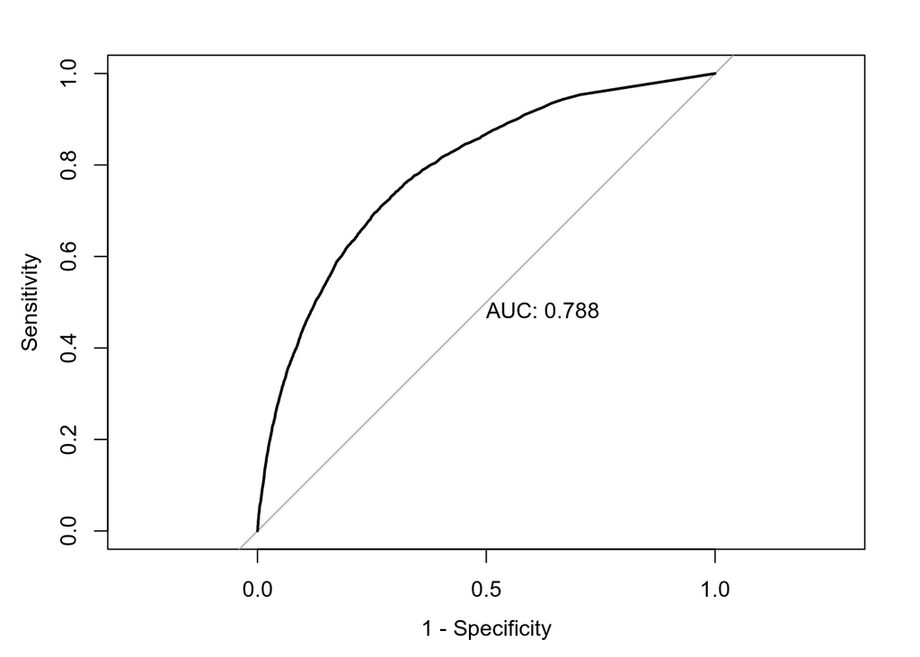

```
## Area under the curve: 0.7879
```

### **Random Forest (mtry = 3) training data Confusion Matrix/Statistics/ROC**

```
## Confusion Matrix and Statistics
##
##           Reference
## Prediction   Yes    No
##        Yes  2090   907
##        No   4183 18869
##
##                Accuracy : 0.8046
##                  95% CI : (0.7997, 0.8094)
##     No Information Rate : 0.7592
##     P-Value [Acc > NIR] : < 2.2e-16
##
##                   Kappa : 0.3496
##
##  Mcnemar's Test P-Value : < 2.2e-16
##
##             Sensitivity : 0.33317
##             Specificity : 0.95414
##          Pos Pred Value : 0.69736
##          Neg Pred Value : 0.81854
##              Prevalence : 0.24082
##          Detection Rate : 0.08023
##    Detection Prevalence : 0.11505
##       Balanced Accuracy : 0.64366
##
##        'Positive' Class : Yes
##
```

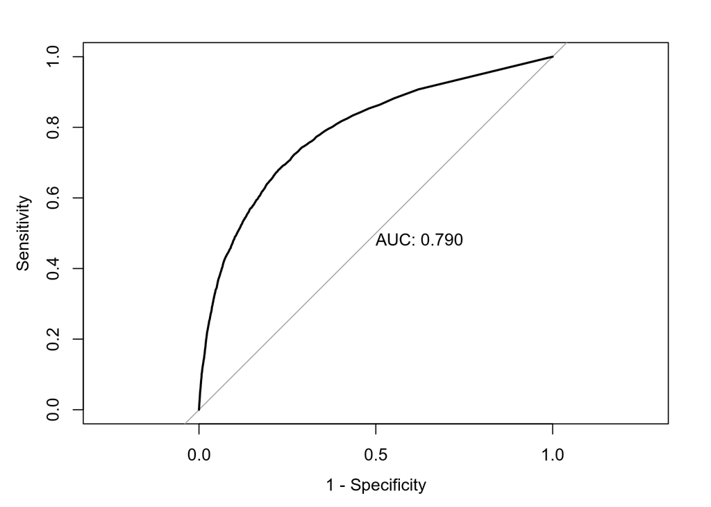

```
## Area under the curve: 0.7901
```

```
##                           MeanDecreaseGini
## WorkclassFederal-gov           24.15037839
## WorkclassLocal-gov             17.27440625
## WorkclassNever-worked           0.04340972
## WorkclassPrivate               26.89870777
## WorkclassSelf-emp-inc          90.27993023
## WorkclassSelf-emp-not-inc      24.46341956
## WorkclassState-gov             13.77323567
## WorkclassWithout-pay            0.56021788
## WorkclassNA                    12.36481186
## RaceAsian-Pac-Islander         12.14436250
## RaceBlack                      30.32355360
## RaceOther                       6.89834459
## RaceWhite                      27.92369397
## RaceNA                         14.45064910
## SexMale                       249.62659220
## SexNA                          24.35100184
## Age                           670.13097397
## Education.num                 793.94106378
## Hours.per.week                427.92839356
```

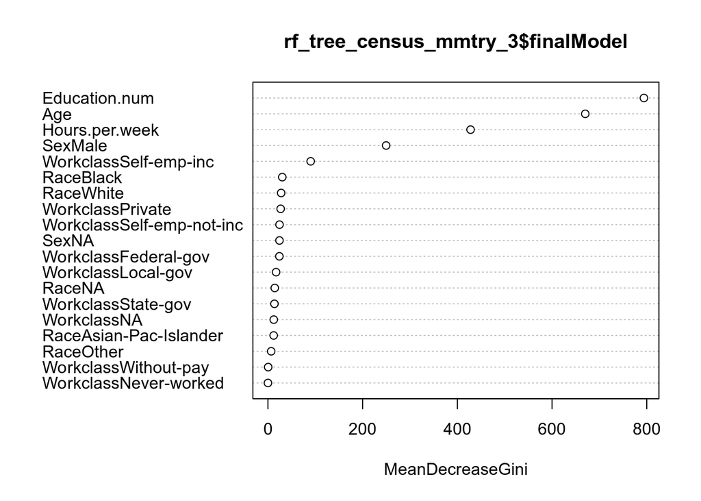

### **Xgboost training data Confusion Matrix/Statistics/ROC**

```
## Confusion Matrix and Statistics
##
##           Reference
## Prediction     Yes      No
##        Yes  287900  148480
##        No   389584 1987328
##
##                Accuracy : 0.8087
##                  95% CI : (0.8083, 0.8092)
##     No Information Rate : 0.7592
##     P-Value [Acc > NIR] : < 2.2e-16
##
##                   Kappa : 0.4046
##
##  Mcnemar's Test P-Value : < 2.2e-16
##
##             Sensitivity : 0.4250
##             Specificity : 0.9305
##          Pos Pred Value : 0.6597
##          Neg Pred Value : 0.8361
##              Prevalence : 0.2408
##          Detection Rate : 0.1023
##    Detection Prevalence : 0.1551
##       Balanced Accuracy : 0.6777
##
##        'Positive' Class : Yes
##
```

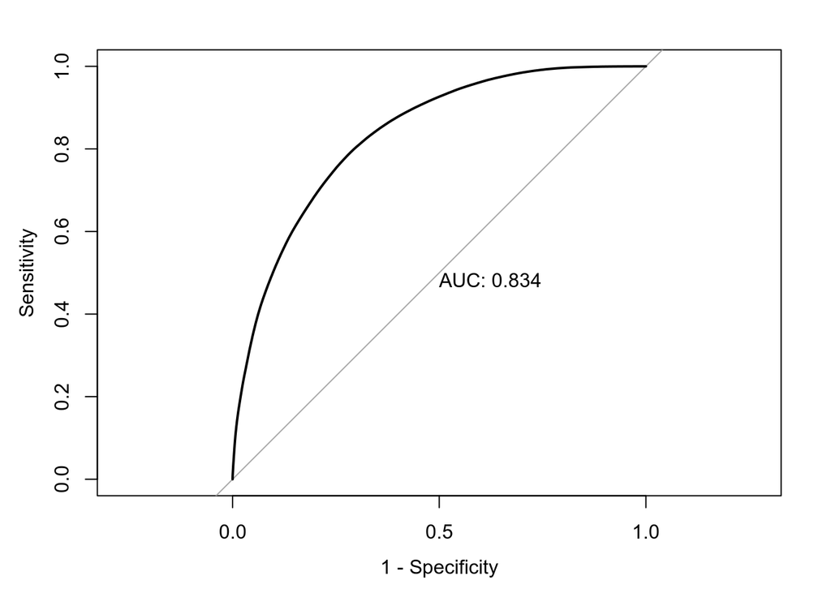

```
## Area under the curve: 0.8341
```

**g.** The predictions resulting from xgboost exhibited the strongest and most optimal combination of: sensitivity, specificity, kappa, accuracy, and auc, compared against all other decision trees (including the pruned/non-pruned trees from part 1) used thus far. Compared specifically against the random forest model with mtry=3, the xgboost model had slightly lower specificity, but a pronounced increase in sensitivity and auc, making it a much more suitable model to use with the census test dataset.

### **Xgboost test data Confusion Matrix/Statistics/ROC**

```
## Confusion Matrix and Statistics
##
##           Reference
## Prediction  Yes   No
##        Yes  699  364
##        No   869 4580
##
##                Accuracy : 0.8107
##                  95% CI : (0.8009, 0.8201)
##     No Information Rate : 0.7592
##     P-Value [Acc > NIR] : < 2.2e-16
##
##                   Kappa : 0.4181
##
##  Mcnemar's Test P-Value : < 2.2e-16
##
##             Sensitivity : 0.4458
##             Specificity : 0.9264
##          Pos Pred Value : 0.6576
##          Neg Pred Value : 0.8405
##              Prevalence : 0.2408
##          Detection Rate : 0.1073
##    Detection Prevalence : 0.1632
##       Balanced Accuracy : 0.6861
##
##        'Positive' Class : Yes
##
```

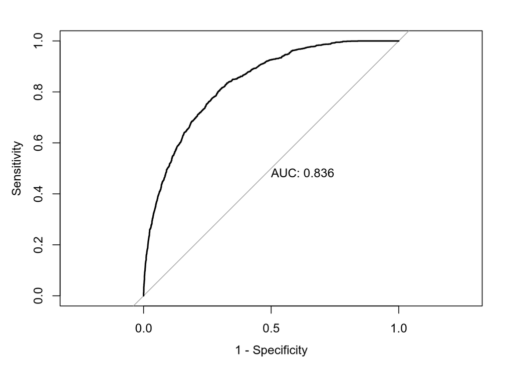

```
## Area under the curve: 0.8359
```